# Galamsey event study — Q0: own-hex mining → own-hex vegetation (mechanics sanity check)

Sree Ayyar, Till Meissner

08 Juli 2026

This document **implements Q0** of the three-part event-study battery specified in `event_study_design.md`. It was split out of the original combined `a_05_event_study.Rmd` on 2026-07-08 into three self-contained, independently-knittable files so each question can be run on its own:

- **`a_05_event_study_1.Rmd`** (this file) — **Q0**: own-hex mining → own-hex vegetation.
- `a_05_event_study_2.Rmd` — **Q1**: upstream mining → downstream vegetation.
- `a_05_event_study_3.Rmd` — **Q2**: neighbour mining → own mining.

**Q0 — Own-hex mining → own-hex vegetation.** Treatment = mining **within the focal hex itself**; no flow graph, no directionality. This is the mechanics sanity check that should be run and read *before* trusting the more elaborate upstream/downstream (Q1) and neighbour-diffusion (Q2) designs in the sibling files: if there is no detectable vegetation effect in the hex that is actually mined, something is wrong upstream of the fancier designs (panel construction, outcome definition, event-time coding); if there is, it’s the natural baseline Q1/Q2 results should be read against.

It reads the shared panel built by `2_build/b_03e_assemble_eventpanel.R` (`data/processed/event_panel_{1|2|5}km.rds`; resolution set via `params$resolution_km`) and runs on every outcome in `OUTCOMES` (see the `outcomes-setup` chunk below) — it does **not** require an upstream/downstream flow graph, so it works even before that graph exists.

Estimator: **Callaway & Sant’Anna** (`did::att_gt` → `aggte(type="dynamic")`) with **not-yet-treated** controls, on an absorbing own-hex stock-threshold treatment (0/5/10 ha), plus a **dCDH** (`did_multiplegt_dyn`) continuous-dose robustness check on the same `own_stock_ha` variable (runs only if `DIDmultiplegtDYN`/`polars` are installed — `HAS_DCDH = TRUE). SEs clustered on real HydroBASINS level-9 sub-basins (`basin_num`, from`d_07_hydrobasins.R`; falls back to a 25 km centroid-block stand-in if absent for this resolution — see`load-panel` chunk and caveats).

# 1 Data foundations

```r
es <- readRDS(here("data", "processed", sprintf("event_panel_%dkm.rds", params$resolution_km)))
panel  <- es$panel
hex_sf <- es$hex_sf

# Spatial clustering key: real HydroBASINS level-9 sub-basins (from d_07_hydrobasins.R via
# b_03e_assemble_eventpanel.R's `basin_id`/`basin_num` columns) when present, replacing the
# 25 km centroid-block stand-in used before 2026-07-06. `block_id`/`block_num` names are kept
# unchanged downstream (did::att_gt `clustervars = "block_num"`) so no other chunk needs to change.
# Falls back to the centroid-block stand-in — with a warning — if `basin_num` isn't in this panel
# (e.g. a resolution `d_07_hydrobasins.R` hasn't been run for yet).
has_basin <- all(c("basin_id", "basin_num") %in% names(panel)) && !all(is.na(panel$basin_num))

if (has_basin) {
  panel <- panel |> mutate(block_id = as.character(basin_id), block_num = basin_num)
  message(sprintf("Clustering on %d HydroBASINS level-9 sub-basins (basin_num).",
                  n_distinct(panel$block_num)))
} else {
  warning("basin_id/basin_num not found in this panel -- falling back to the 25 km centroid-block ",
          "SE-clustering stand-in. Run d_07_hydrobasins.R then b_03e_assemble_eventpanel.R for ",
          "this resolution to get real sub-basin clustering.")
  cent <- sf::st_coordinates(suppressWarnings(sf::st_centroid(sf::st_geometry(hex_sf))))
  blocks <- tibble(hex_id   = hex_sf$hex_id,
                   block_id = paste0("b_", round(cent[, 1] / 25000), "_",
                                     round(cent[, 2] / 25000)))
  panel <- left_join(panel, blocks, by = "hex_id") |>
    mutate(block_num = as.integer(factor(block_id)))
}

has_terrain  <- all(c("elev_mean", "slope_mean") %in% names(panel)) &&
                !all(is.na(panel$elev_mean))
xf <- if (has_terrain) ~ elev_mean + slope_mean else ~ 1

c(terrain_covariates_present = has_terrain,
  hydrobasins_clustering     = has_basin,
  n_clusters                 = n_distinct(panel$block_num))
```

```
## terrain_covariates_present     hydrobasins_clustering
##                          1                          1
##                 n_clusters
##                        287
```

Vegetation-index outcomes for Q0 (2026-07-08 revision) are restricted to **peak (annual max) only** — no annual-mean variants — for **both NDVI and EVI**, across three ESA-CCI/Barenblitt land-cover masks:

- **`no-mine-crop`** — excludes any pixel ever classified as Barenblitt mining, using the mining footprint directly rather than relying on ESA-CCI’s annual land-cover reclassification. Isolates the within-hex spillover signal (vegetation loss on land that was never itself mined) from the mechanical VI collapse on pixels that were physically bulldozed.
- **`veg_narrow`** — the **headline mask**. Built in `b_03a_vi_panel.R`’s `CCI_MASKS` as the union of the `cropland` classes (ESA-CCI/UN-LCCS codes 10, 11, 12, 20, 30 — rainfed + irrigated cropland + cropland-dominant mosaic) and the `forest` classes (50, 60, 61, 62, 70, 90 — all tree-cover types: broadleaf evergreen/deciduous, needleleaf evergreen, mixed). Informally, the “productive green” mask — dense cropland plus tree cover, and nothing sparser (excludes vegetation mosaics, shrubland, grassland, and sparse/flooded vegetation, which only the broader `veg_broad` mask includes). `cropland ⊂ veg_narrow ⊂ veg_broad` by construction.
- **`cropland`** — ESA-CCI classes 10, 11, 12, 20, 30 only (a subset of `veg_narrow`, dropped down to just the agricultural pixels) — kept as the narrower agricultural-damage-channel comparison.

```r
# Vegetation-index outcomes, built from the reworked b_03a_vi_panel.R "peak EVI" pipeline
# (Vashold et al. 2026 methodology; see galamsey_tasklist.md's Data section and
# code/2_build/explainer.md). Restricted 2026-07-08 to peak (max) only, for both NDVI and EVI,
# across three masks -- see the prose above this chunk for what each mask means (veg_narrow's
# cropland-union-forest definition, drawn from b_03a_vi_panel.R's CCI_MASKS, in particular).
# evi_modis_veg_narrow_max is listed first and stays the HEADLINE throughout this file (all
# hardcoded lookups in q0b-plot/panelview-thresholds point at it specifically); its NDVI
# counterpart and the other masks are folded into the same code blocks as additional outcomes.
# NDVI and EVI ATT MAGNITUDES are not directly comparable (different index scales) -- see caveats.
OUTCOMES <- c(
  evi_modis_veg_narrow_max   = "EVI (peak, veg-narrow)",
  ndvi_modis_veg_narrow_max  = "NDVI (peak, veg-narrow)",
  evi_modis_nominecrop_max   = "EVI (peak, no-mine-crop)",
  ndvi_modis_nominecrop_max  = "NDVI (peak, no-mine-crop)",
  evi_modis_cropland_max     = "EVI (peak, cropland)",
  ndvi_modis_cropland_max    = "NDVI (peak, cropland)"
)
OUTCOMES <- OUTCOMES[names(OUTCOMES) %in% names(panel)]
OUTCOMES <- OUTCOMES[vapply(names(OUTCOMES), \(c) !all(is.na(panel[[c]])), logical(1))]

names(OUTCOMES)
```

```
## [1] "evi_modis_veg_narrow_max"  "ndvi_modis_veg_narrow_max"
## [3] "evi_modis_nominecrop_max"  "ndvi_modis_nominecrop_max"
## [5] "evi_modis_cropland_max"    "ndvi_modis_cropland_max"
```

```r
ndvi_years   <- es$ndvi_years
mining_years <- es$mining_years
overlap_txt <- sprintf(
  "The NDVI stack covers %d–%d; Barenblitt mining spans %d–%d; the usable event window (their overlap) is **%d–%d**.",
  min(ndvi_years), max(ndvi_years),
  min(mining_years), max(mining_years),
  max(min(ndvi_years), min(mining_years)),
  min(max(ndvi_years), max(mining_years)))
cat(overlap_txt)
```

The NDVI stack covers 2000–2025; Barenblitt mining spans 2007–2017; the usable event window (their overlap) is **2007–2017**.

```r
# NA share for every VI column (index x mask x stat) in THIS panel -- the evidence behind the
# mask/stat choices made in `outcomes-setup` above (headline stat = max/peak; headline mask =
# cropland; decided 2026-07-07 after reviewing this exact diagnostic).
vi_all_cols <- setdiff(es$vi_cols, "urban_share")

na_by_col <- tibble(
  col      = vi_all_cols,
  na_share = vapply(vi_all_cols, \(c) mean(is.na(panel[[c]])), numeric(1))
) |>
  mutate(
    index     = str_extract(col, "^ndvi|^evi"),
    remainder = str_remove(col, "^(ndvi|evi)_modis_"),          # "{mask}_{stat}" or just "{stat}"
    stat      = str_extract(remainder, "mean$|max$"),
    mask      = str_remove(remainder, "_?(mean|max)$"),
    mask      = if_else(mask == "", "overall", mask)
  ) |>
  dplyr::select(index, mask, stat, na_share)

na_by_mask <- na_by_col |>
  group_by(mask) |>
  summarise(na_share = mean(na_share), .groups = "drop") |>
  arrange(na_share)

save_md(na_by_mask, "es_vi_missingness_by_mask.md", digits = 3)

kbl(na_by_mask, digits = 3, caption = paste0(
    "VI column NA share by land-cover mask (averaged over {NDVI,EVI} x {mean,max}). overall/",
    "nominecrop are ~pixel-complete; forest stays the sparsest -- veg_broad/veg_narrow/cropland ",
    "are the usable middle ground.")) |>
  kable_styling(full_width = FALSE)
```

VI column NA share by land-cover mask (averaged over {NDVI,EVI} x {mean,max}). overall/nominecrop are ~pixel-complete; forest stays the sparsest – veg_broad/veg_narrow/cropland are the usable middle ground.

| mask | na_share |
| --- | --- |
| nominecrop | 0.002 |
| overall | 0.002 |
| veg_broad | 0.017 |
| veg_narrow | 0.022 |
| cropland | 0.095 |
| forest | 0.707 |

**Treatment structure by threshold.** The C&S treatment clock is the first year the focal hex’s **own** mining stock crosses $\bar m$ (the `first_cross` rule below). We show it at all three thresholds in `mbar_grid` ($\bar m = 0$, 5, and 10 ha — one panelview each, three in total). Outcome/completeness check is `evi_modis_veg_narrow_max` (the headline outcome as of 2026-07-08 — see `outcomes-setup` for its definition), restricted to hexes with no NA in that column over the Barenblitt window (2007–2017), same restriction style as `_2.Rmd`’s upstream panelviews.

```
## Specified labels in the order of: Controls, Treated (Pre), Treated (Post).
```

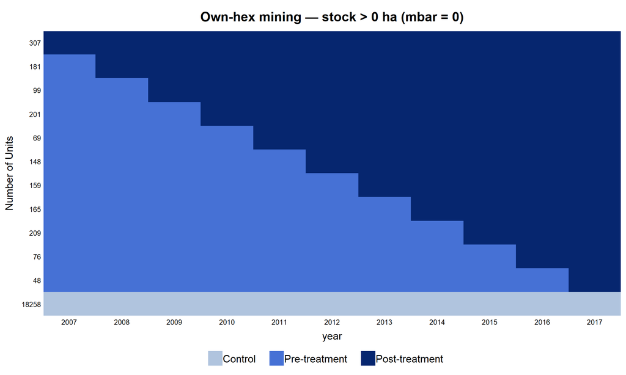

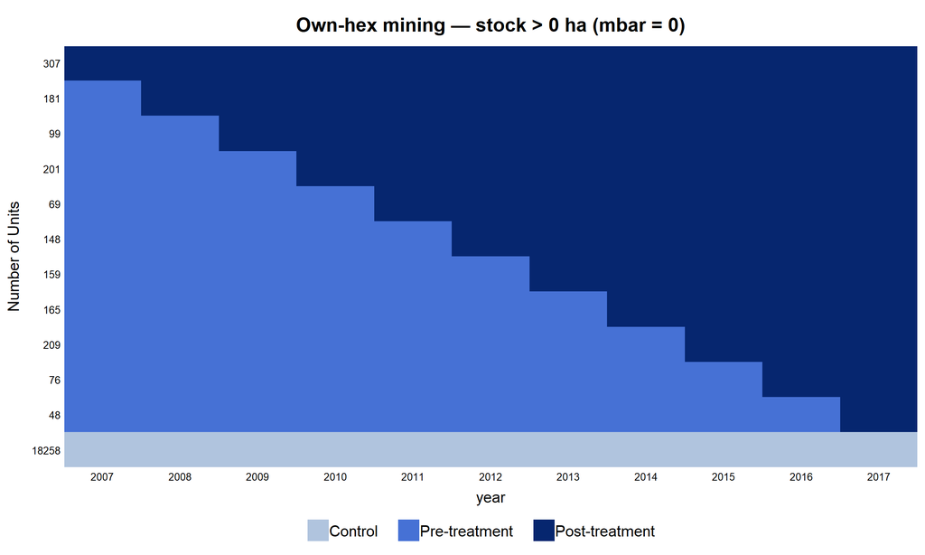

```
## Specified labels in the order of: Controls, Treated (Pre), Treated (Post).
```

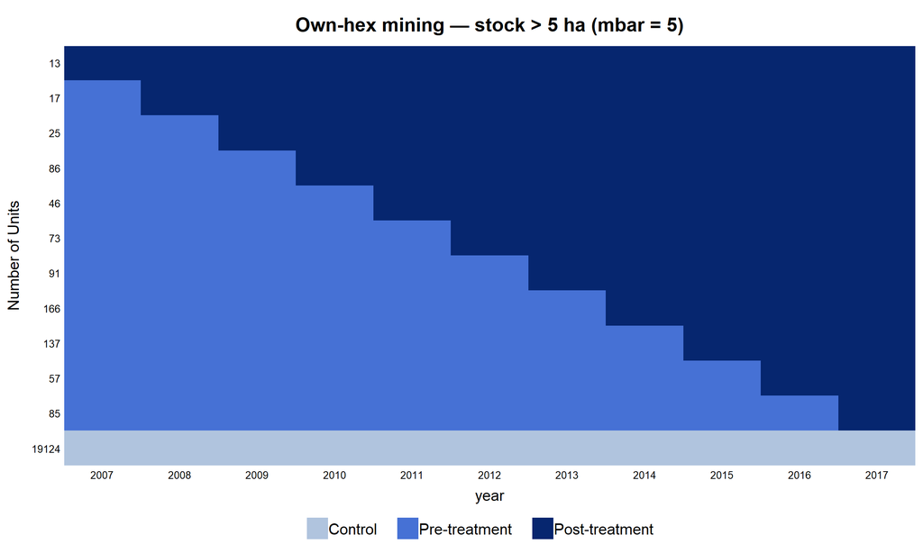

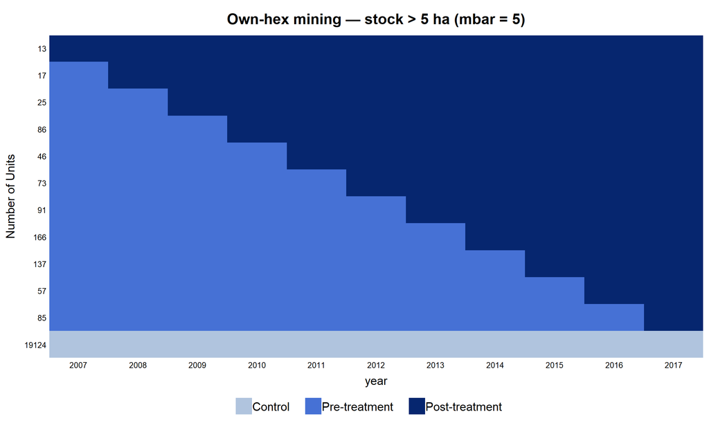

```
## Specified labels in the order of: Controls, Treated (Pre), Treated (Post).
```

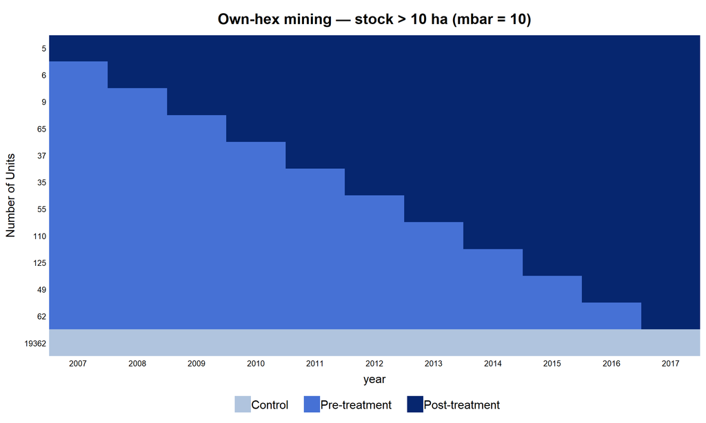

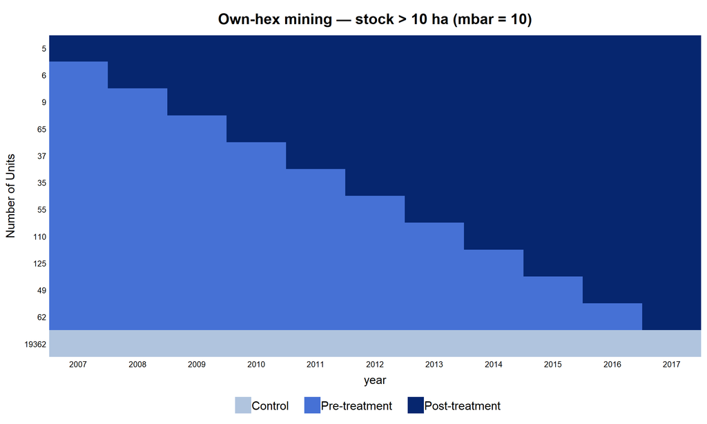

```r
# Thresholds must match mbar_grid (defined in the helpers chunk below) — kept as a literal here
# since this chunk runs before helpers.
pv_mbar_grid <- c(0, 5, 10)
pv_complete_ids <- panel |>
  filter(year >= 2007, year <= 2017) |>
  group_by(hex_id) |> filter(!any(is.na(evi_modis_veg_narrow_max))) |>
  ungroup() |> distinct(hex_id)

# Treatment clock = first year `stock_col` exceeds mbar (NA = never treated), matching
# first_cross() in the helpers chunk below (inlined here since this chunk runs first).
pv_show <- function(stock_col, mbar, main, file) {
  d <- panel |>
    filter(year >= 2007, year <= 2017) |>
    semi_join(pv_complete_ids, by = "hex_id") |>
    group_by(hex_id) |>
    mutate(g_thr = {
      col <- .data[[stock_col]]
      y   <- year[!is.na(col) & col > mbar]
      if (length(y)) min(y) else NA_integer_
    }) |>
    ungroup() |>
    mutate(D = as.integer(!is.na(g_thr) & year >= g_thr))
  p <- panelview(evi_modis_veg_narrow_max ~ D, data = d, index = c("hex_id", "year"), main = main,
                 legend.labs = c("Control", "Pre-treatment", "Post-treatment"),
                 pre.post = TRUE, by.timing = TRUE, collapse.history = TRUE,
                 display.all = TRUE, report.missing = FALSE, background = "white")
  print(p)
  save_es(p, file, width = 10, height = 6)
  invisible(p)
}

# One panelview per threshold in pv_mbar_grid (0/5/10 ha) -- three in total, all on own_stock_ha.
pv_specs <- purrr::map(pv_mbar_grid, \(mb) list(
  "own_stock_ha", mb,
  sprintf("Own-hex mining — stock > %d ha (mbar = %d)", mb, mb),
  sprintf("es_q0_panelview_own_mbar%d.png", mb)
))
pv_specs <- Filter(\(s) s[[1]] %in% names(panel) && !all(is.na(panel[[s[[1]]]])), pv_specs)
for (s in pv_specs) pv_show(s[[1]], s[[2]], s[[3]], s[[4]])
```

# 2 Control variables in the C&S estimator

`did::att_gt` uses `xformla` in both legs of the doubly-robust (DR) estimator: the propensity score model (what predicts a hex’s treatment cohort) and the outcome regression (what predicts EVI conditional on pre-treatment covariates). DR is consistent if *either* leg is correctly specified — but adding the right pre-treatment predictors of treatment timing strengthens the propensity score and makes treated/control groups more comparable.

**Currently used:** `xf = ~ elev_mean + slope_mean` (or `~ 1` when terrain is absent). These capture topographic accessibility: high, steep terrain is harder to mine and has systematically different vegetation.

```r
mbar_grid <- c(0, 5, 10)    # ha thresholds for the stock-threshold sweep; must match pv_mbar_grid
                            # in the panelview-thresholds chunk above (revised 2026-07-08)

# C&S event study wrapper. `gcol` is a numeric column in `data` (0 = never-treated, else first-treat
# year). Returns the att_gt object + dynamic (event-time) and overall aggregations.
run_cs <- function(data, yname, gcol, xformla = xf, cluster = "block_num",
                   control = "notyettreated", min_e = -5, max_e = 5) {
  data <- data |> filter(is.finite(.data[[yname]]))
  att <- did::att_gt(
    yname = yname, tname = "year", idname = "hex_num", gname = gcol,
    control_group = control, xformla = xformla, clustervars = cluster,
    data = as.data.frame(data), est_method = "dr",
    base_period = "universal", allow_unbalanced_panel = TRUE, bstrap = TRUE
  )
  list(att     = att,
       dynamic = did::aggte(att, type = "dynamic", min_e = min_e, max_e = max_e, na.rm = TRUE),
       overall = did::aggte(att, type = "group", na.rm = TRUE))
}

# first-treat column from a "stock crosses mbar" rule
first_cross <- function(df, stock_col, mbar) {
  df |> group_by(hex_id) |>
    mutate(g_thr = {
      col <- .data[[stock_col]]
      y   <- year[!is.na(col) & col > mbar]   # NA treated as below threshold; avoids year[NA]=NAs
      if (length(y)) min(y) else 0L
    }) |>
    ungroup()
}

# Summarise a map(mbar_grid, run_cs) list into a tidy ATT table row.
cs_row <- function(cs_list, label)
  imap_dfr(cs_list, ~tibble(exposure = label, mbar = .y,
                             att = .x$overall$overall.att, se = .x$overall$overall.se))

# tidy_dyn: one C&S dynamic aggregation -> tidy event-time frame.
tidy_dyn <- function(dyn, label)
  tibble(threshold  = label,
         event_time = dyn$egt,
         att        = dyn$att.egt,
         se         = dyn$se.egt) |>
  mutate(ci_lo = att - 1.96 * se, ci_hi = att + 1.96 * se)

# Three-threshold palette (revised 2026-07-08 for mbar_grid = c(0, 5, 10)); ">0 ha" is mbar = 0
# (any onset).
v2_thresh_cols <- c(">0 ha" = "#6A3D9A", ">5 ha" = "#2171B5", ">10 ha" = "#E67E22")

# v2_dynplot: overlay the C&S dynamic ATT across all stock thresholds in mbar_grid for one exposure.
# CI shown as an unfilled (outline-only) band — fill = NA, thin dotted edge.
v2_dynplot <- function(cs_list, title, subtitle) {
  bind_rows(
    tidy_dyn(cs_list[["mbar_0"]]$dynamic,  ">0 ha"),
    tidy_dyn(cs_list[["mbar_5"]]$dynamic,  ">5 ha"),
    tidy_dyn(cs_list[["mbar_10"]]$dynamic, ">10 ha")
  ) |>
    mutate(threshold = factor(threshold, levels = names(v2_thresh_cols))) |>
    ggplot(aes(event_time, att, colour = threshold)) +
    geom_hline(yintercept = 0, linetype = "dashed", colour = "grey50") +
    geom_vline(xintercept = -0.5, linetype = "dotted", colour = "grey40") +
    geom_ribbon(aes(ymin = ci_lo, ymax = ci_hi, colour = threshold),
                fill = NA, linewidth = 0.25, linetype = "dotted") +
    geom_line() + geom_point(size = 1.8) +
    scale_colour_manual(values = v2_thresh_cols) +
    labs(title = title, subtitle = subtitle,
         x = "Event time (years relative to threshold crossing)",
         y = "ATT on EVI", colour = "Stock threshold") +
    theme_bw(base_size = 11)
}

# outcome_dynplot: overlay the C&S dynamic ATT across OUTCOMES for one exposure/threshold.
outcome_dynplot <- function(dyn_list, labels, title, subtitle) {
  df <- bind_rows(purrr::map2(dyn_list, labels, \(d, l) tidy_dyn(d, l)))
  df$outcome <- factor(df$threshold, levels = labels)
  ggplot(df, aes(event_time, att, colour = outcome, fill = outcome)) +
    geom_hline(yintercept = 0, linetype = "dashed", colour = "grey50") +
    geom_vline(xintercept = -0.5, linetype = "dotted", colour = "grey40") +
    geom_ribbon(aes(ymin = ci_lo, ymax = ci_hi), alpha = 0.12, colour = NA) +
    geom_line() + geom_point(size = 1.6) +
    labs(title = title, subtitle = subtitle,
         x = "Event time (years relative to treatment)", y = "ATT on outcome",
         colour = "Outcome", fill = "Outcome") +
    theme_bw(base_size = 11)
}
```

# 3 Q0 — Own-hex mining → own-hex vegetation (mechanics sanity check)

**Purpose.** Before trusting the upstream/downstream designs in Q1 (flow graph, directionality, waterborne mechanism) or the neighbour-diffusion design in Q2, check the most basic version of the claim: **is there a detectable vegetation effect in the hex that is actually mined**, full stop? Treatment here is mining **within the focal hex itself** (`own_onset_year` / `own_new_ha` / `own_stock_ha`, already in the panel from `b_03b_own_mining.R` — no flow-graph, no directionality, no new data). If this doesn’t show an effect, something is wrong upstream of the fancier designs (panel construction, outcome definition, event-time coding); if it does, it’s the natural baseline Q1/Q2 results should be read against. Runs on every outcome in `OUTCOMES`.

**Design.** Treatment clock = the first year `own_stock_ha` (cumulative own-hex mined hectares) crosses $\bar m$, swept over `mbar_grid` (0/5/10 ha) — checks whether the effect scales with *how much* of the hex is mined, not just *whether* it is (an onset-only, no-threshold version — the former “Q0a” — was tried first and dropped 2026-07-08 as redundant with the $\bar m = 0$ case here, which already captures any own-hex onset). Two estimators:

- **Callaway & Sant’Anna** (absorbing treatment at the threshold-crossing year) — the headline. The 0/5/10 ha comparison is plotted both as an overlay across all three thresholds (one plot per land-cover mask) and, separately, as one outcome-comparison plot per (mask x threshold) — 3 masks x 3 thresholds = 9 plots in total.
- **dCDH** (`did_multiplegt_dyn`, continuous dose) — treats `own_stock_ha` as a continuous treatment intensity rather than discretising it at a threshold; robustness check against the threshold choice itself. Runs only if `DIDmultiplegtDYN`/`polars` are installed.

## 3.1 Callaway & Sant’Anna — absorbing treatment (own_stock_ha, mbar sweep)

```r
# run_v0b_own: the mbar sweep for a single exposure (own-hex mining) -- reuses v2_dynplot/cs_row
# directly (both expect a list keyed "mbar_0"/"mbar_5"/"mbar_10", matching mbar_grid, which this
# produces).
run_v0b_own <- function(yname) {
  l <- map(mbar_grid, \(mb) run_cs(first_cross(panel, "own_stock_ha", mb), yname, "g_thr"))
  set_names(l, paste0("mbar_", mbar_grid))
}

q0b_fits <- imap(OUTCOMES, \(lab, yc) run_v0b_own(yc))

q0b_all <- imap_dfr(q0b_fits, \(cs_list, oc) cs_row(cs_list, OUTCOMES[[oc]])) |>
  rename(outcome = exposure) |>
  mutate(ci_lo = att - 1.96 * se, ci_hi = att + 1.96 * se)

q0b_wide <- q0b_all |>
  mutate(cell = sprintf("%+.4f (%.4f)", att, se)) |>
  select(outcome, mbar, cell) |>
  pivot_wider(names_from = mbar, values_from = cell, names_prefix = "stock > ") |>
  rename_with(~paste0(., " ha"), starts_with("stock > "))

save_md(q0b_wide, "es_q0b_stability_table.md")
kbl(q0b_wide, caption = paste0(
  "Overall ATT (SE) of own-hex mining on own-hex vegetation, across stock thresholds and ",
  "outcomes. Compare against Q1's upstream/downstream results -- own-hex effects should be the ",
  "LARGEST in magnitude (direct land-clearing, not a spillover), setting the scale for what a ",
  "real waterborne effect could plausibly look like.")) |>
  kable_styling(full_width = FALSE)
```

Overall ATT (SE) of own-hex mining on own-hex vegetation, across stock thresholds and outcomes. Compare against Q1’s upstream/downstream results – own-hex effects should be the LARGEST in magnitude (direct land-clearing, not a spillover), setting the scale for what a real waterborne effect could plausibly look like.

| outcome | stock > mbar_0 ha | stock > mbar_5 ha | stock > mbar_10 ha |
| --- | --- | --- | --- |
| EVI (peak, veg-narrow) | -0.0155 (0.0240) | -0.0218 (0.0092) | -0.0213 (0.0109) |
| NDVI (peak, veg-narrow) | -0.0170 (0.0184) | -0.0187 (0.0077) | -0.0228 (0.0137) |
| EVI (peak, no-mine-crop) | -0.0126 (0.0066) | -0.0186 (0.0100) | -0.0182 (0.0119) |
| NDVI (peak, no-mine-crop) | -0.0157 (0.0048) | -0.0156 (0.0083) | -0.0189 (0.0141) |
| EVI (peak, cropland) | -0.0159 (0.0255) | -0.0214 (0.0097) | -0.0209 (0.0118) |
| NDVI (peak, cropland) | -0.0174 (0.0164) | -0.0185 (0.0074) | -0.0233 (0.0135) |

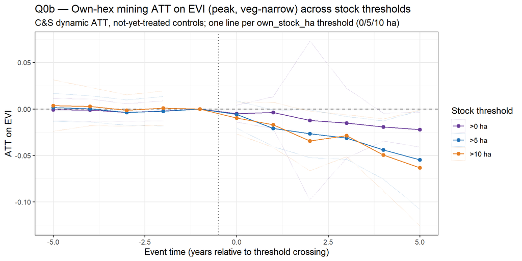

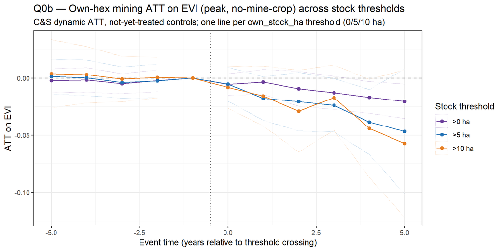

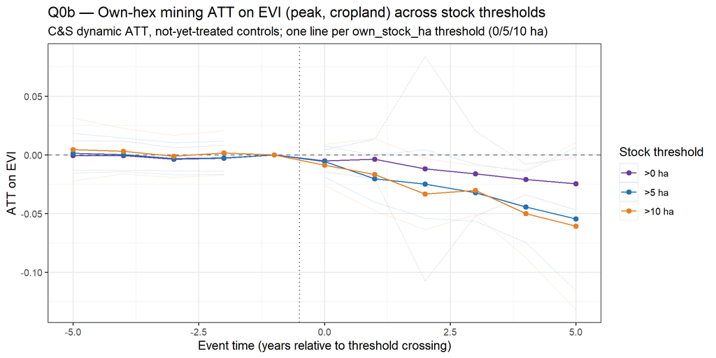

```r
# Q0b threshold-sweep plot (0/5/10 ha, from mbar_grid), one v2_dynplot PER LAND-COVER MASK on the
# headline EVI (peak) index -- veg_narrow is the original headline plot (kept, same filename
# es_q0b_headline.png); nominecrop and cropland added alongside as mask-robustness comparisons at
# the same three thresholds.
q0b_mask_specs <- list(
  veg_narrow = list(col = "evi_modis_veg_narrow_max", label = "veg-narrow",   file = "es_q0b_headline.png"),
  nominecrop = list(col = "evi_modis_nominecrop_max", label = "no-mine-crop", file = "es_q0b_nominecrop.png"),
  cropland   = list(col = "evi_modis_cropland_max",   label = "cropland",    file = "es_q0b_cropland.png")
)
q0b_mask_specs <- Filter(\(s) s$col %in% names(q0b_fits), q0b_mask_specs)

q0b_mask_plots <- imap(q0b_mask_specs, \(s, mask_key) {
  p <- v2_dynplot(q0b_fits[[s$col]],
    sprintf("Q0b — Own-hex mining ATT on EVI (peak, %s) across stock thresholds", s$label),
    "C&S dynamic ATT, not-yet-treated controls; one line per own_stock_ha threshold (0/5/10 ha)")
  print(p)
  save_es(p, s$file, height = 4.5)
  p
})
```

```r
p_q0b_headline <- q0b_mask_plots[["veg_narrow"]]   # kept for downstream reference
```

```r
# All outcomes overlaid, split into one plot PER LAND-COVER MASK (so NDVI vs EVI lines within a
# mask are directly comparable, rather than all 6 outcomes -- 3 masks x 2 indices -- mixed onto one
# axis) at EVERY threshold in mbar_grid (0/5/10 ha -- revised 2026-07-08 from just the two endpoint
# thresholds, so mbar=5 gets the same per-mask outcome view as 0 and 10). 3 masks x 3 thresholds = 9
# plots in total. Both the threshold values and the mask groupings are derived from
# mbar_grid/OUTCOMES programmatically -- if OUTCOMES gains/loses a mask or index, or mbar_grid
# changes, this chunk adapts without any hardcoded column names.

# Parse each OUTCOMES column into {index, mask, stat} components -- mirrors the vi-missingness
# chunk's column-name parser above.
outcome_meta <- tibble(col = names(OUTCOMES), label = unname(OUTCOMES)) |>
  mutate(
    index     = toupper(str_extract(col, "^ndvi|^evi")),
    remainder = str_remove(col, "^(ndvi|evi)_modis_"),          # "{mask}_{stat}"
    stat      = str_extract(remainder, "mean$|max$"),
    mask      = str_remove(remainder, "_?(mean|max)$")
  )

Q0B_MBARS <- mbar_grid   # all thresholds, e.g. c(0, 5, 10)

for (mb in Q0B_MBARS) {
  cat(sprintf("\n\n### Stock > %d ha\n\n", mb))
  mb_key <- paste0("mbar_", mb)
  for (msk in unique(outcome_meta$mask)) {
    cols_here <- outcome_meta |> filter(mask == msk)
    if (nrow(cols_here) == 0) next
    msk_label <- str_replace_all(msk, "_", "-")   # display only, e.g. "veg_narrow" -> "veg-narrow"
    dyn_list <- map(cols_here$col, \(oc) q0b_fits[[oc]][[mb_key]]$dynamic) |>
      set_names(cols_here$index)
    p <- outcome_dynplot(dyn_list, cols_here$index,
      sprintf("Own-hex mining — %s — stock > %d ha", msk_label, mb),
      "C&S dynamic ATT; one line per vegetation index (NDVI vs EVI); 95% CI ribbon")
    print(p)
    save_es(p, sprintf("es_q0b_outcomes_mbar%d_%s.png", mb, msk), height = 4.5)
  }
}
```

### 3.1.1 Stock > 0 ha

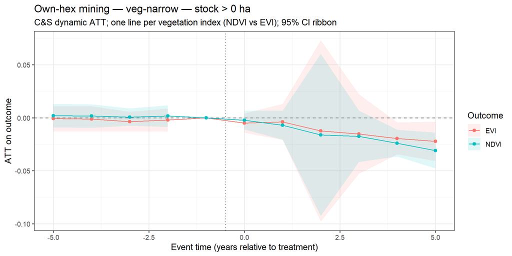

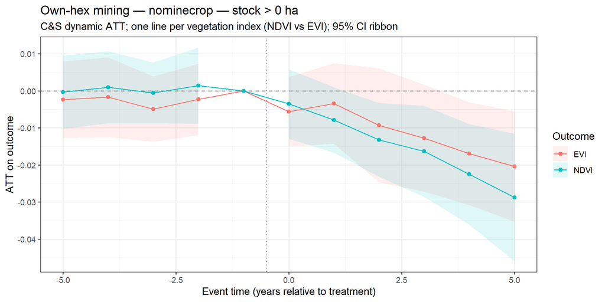

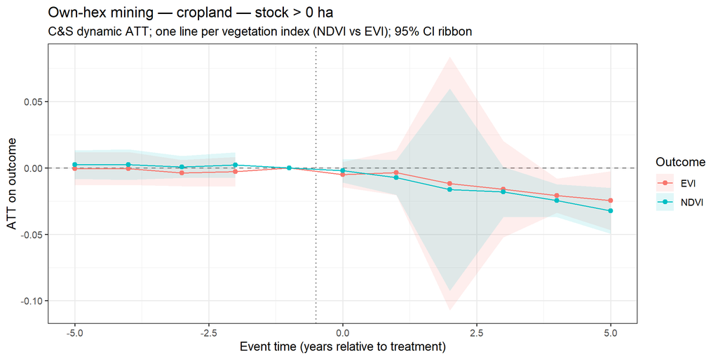

### 3.1.2 Stock > 5 ha

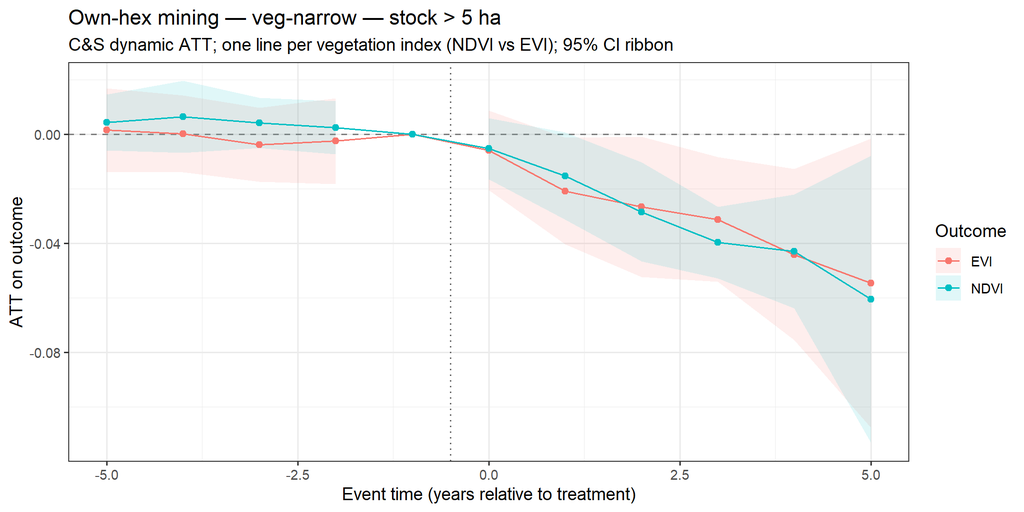

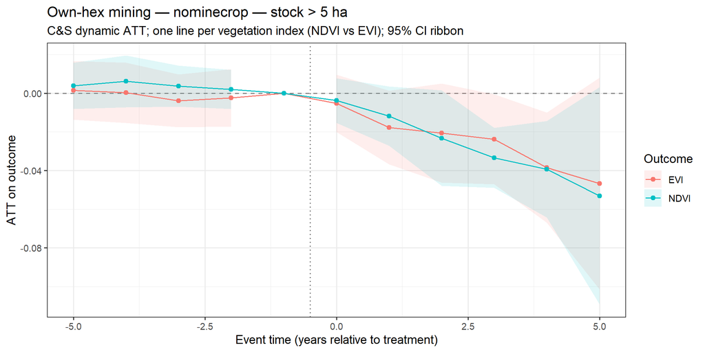

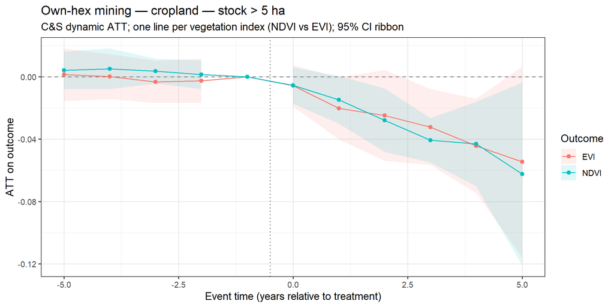

### 3.1.3 Stock > 10 ha

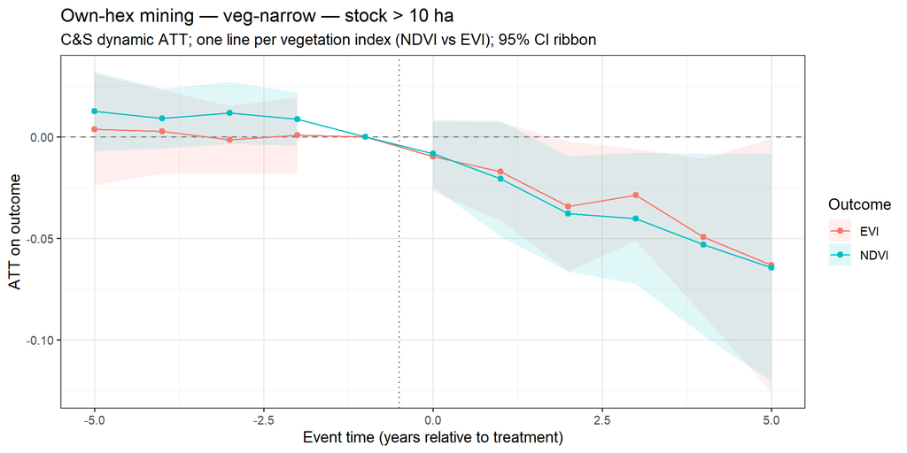

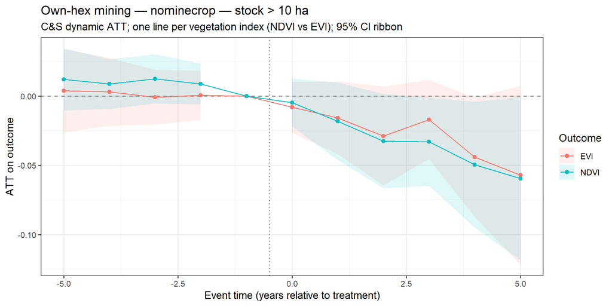

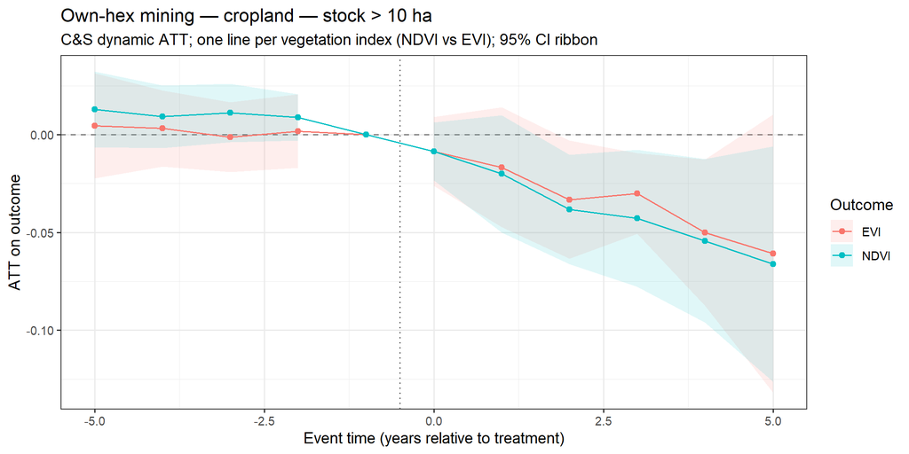

## 3.2 dCDH — continuous dose (own_stock_ha)

Robustness check against the C&S threshold choice above: rather than discretising `own_stock_ha` at $\bar m \in \{0, 5, 10\}$, `did_multiplegt_dyn` (de Chaisemartin & D’Haultfœuille) treats the cumulative own-hex mined hectares as a continuous treatment intensity and estimates effects of *changes in dose*, pooling across all dose levels. One fit per outcome in `OUTCOMES`.

```r
if (!HAS_DCDH)
  cat("> **dCDH skipped** — `DIDmultiplegtDYN` and/or `polars` are not installed. ",
      "Install both to run the continuous-dose robustness check.\n")
```

```r
# DIDmultiplegtDYN 2.3.0 references polars' `pl` as a bare symbol without importing it, so polars
# MUST be attached (not just available) or did_multiplegt_dyn errors with "object 'pl' not found".
library(polars)

# Single treatment dimension (own_stock_ha) -- unlike Q1's 5-exposure dCDH battery, Q0 has no
# upstream/downstream/lateral split, so this is just one run per outcome, on the full panel (no
# full-vs-censored split either: own_stock_ha IS the treatment being tested, so there is no
# separate "already mining" contamination to censor out here).
run_dcdh_own <- function(yname) {
  m <- DIDmultiplegtDYN::did_multiplegt_dyn(
    df        = as.data.frame(panel),
    outcome   = yname,
    group     = "hex_id",
    time      = "year",
    treatment = "own_stock_ha",
    effects   = 5,
    placebo   = 3,
    cluster   = "block_num",
    graph_off = TRUE          # we build our own plot below
  )
  res <- list(results = m$results)   # keep only what q0-dcdh-plot / -table use
  rm(m); gc()
  res
}

dcdh_q0 <- imap(OUTCOMES, \(lab, yc) run_dcdh_own(yc))
```

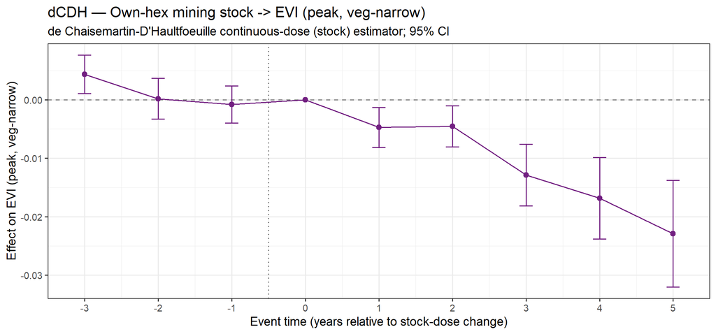

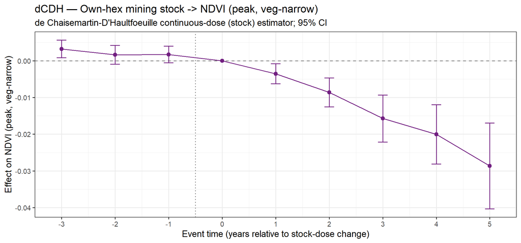

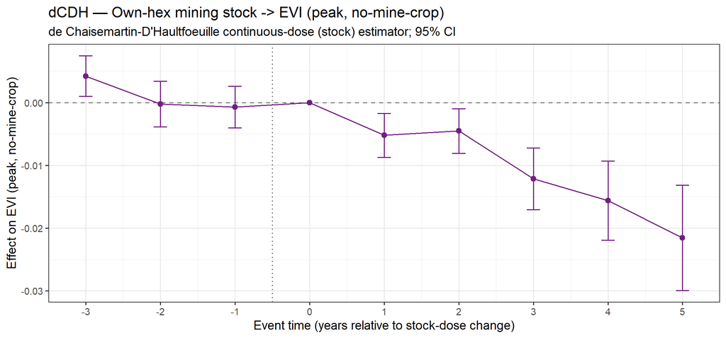

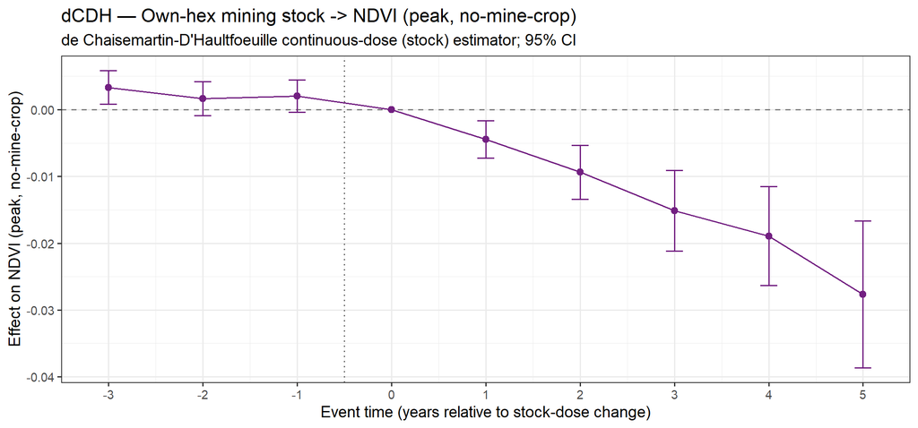

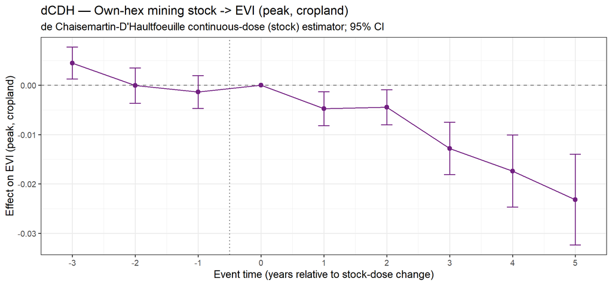

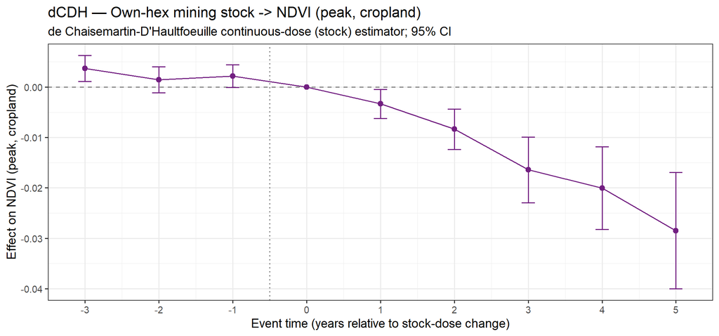

```r
# dCDH convention (from did_multiplegt_dyn): Effect_l -> event time +l (post), Placebo_l -> event
# time -l (pre), reference period normalised to 0 at event time 0.
tidy_dcdh_own <- function(obj) {
  mk <- function(mat, sgn) {
    if (is.null(mat) || !nrow(mat)) return(NULL)
    tibble(event_time = sgn * seq_len(nrow(mat)),
           est = mat[, "Estimate"], lo = mat[, "LB CI"], hi = mat[, "UB CI"])
  }
  bind_rows(mk(obj$results$Effects, 1L),
            mk(obj$results$Placebos, -1L),
            tibble(event_time = 0L, est = 0, lo = NA_real_, hi = NA_real_)) |>
    arrange(event_time)
}

for (oc in names(dcdh_q0)) {
  d <- tidy_dcdh_own(dcdh_q0[[oc]])
  p <- ggplot(d, aes(event_time, est)) +
    geom_hline(yintercept = 0, linetype = "dashed", colour = "grey50") +
    geom_vline(xintercept = -0.5, linetype = "dotted", colour = "grey40") +
    geom_line(colour = "#721F81") + geom_point(colour = "#721F81", size = 1.9) +
    geom_errorbar(aes(ymin = lo, ymax = hi), width = 0.18, colour = "#721F81") +
    scale_x_continuous(breaks = sort(unique(d$event_time))) +
    labs(title    = sprintf("dCDH — Own-hex mining stock -> %s", OUTCOMES[[oc]]),
         subtitle = "de Chaisemartin-D'Haultfoeuille continuous-dose (stock) estimator; 95% CI",
         x = "Event time (years relative to stock-dose change)",
         y = paste0("Effect on ", OUTCOMES[[oc]])) +
    theme_bw(base_size = 11)
  print(p)
  save_es(p, sprintf("es_q0_dcdh_%s.png", oc), height = 4.2)
}
```

```r
# Compact dCDH summary: the headline numbers behind the plots above, one row per outcome.
#   - ATE [95% CI]  : average total effect (single summary effect of the stock dose on the outcome)
#   - p(pre-trend)  : joint placebo test (H0: all pre-period placebos = 0); HIGH p = flat pre-trends
#   - p(effects)    : joint test (H0: all dynamic effects = 0); LOW p = effects jointly significant
#   - Switchers     : number of switching hexes identifying the ATE (effective sample / precision)
scl  <- function(x) if (is.null(x)) NA_real_ else as.numeric(x)
pick <- function(a, col) if (is.matrix(a)) a[1, col] else a[[col]]
dcdh_summary_own <- function(obj) {
  a <- obj$results$ATE
  tibble(ate       = pick(a, "Estimate"),
         ci_lo     = pick(a, "LB CI"),
         ci_hi     = pick(a, "UB CI"),
         p_pre     = scl(obj$results$p_jointplacebo),
         p_effects = scl(obj$results$p_jointeffects),
         switchers = pick(a, "Switchers"))
}

dcdh_q0_tab <- imap_dfr(dcdh_q0, \(obj, oc)
  dcdh_summary_own(obj) |> mutate(outcome = OUTCOMES[[oc]], .before = 1))

dcdh_q0_out <- dcdh_q0_tab |>
  mutate(`ATE [95% CI]` = sprintf("%.4f [%.4f, %.4f]", ate, ci_lo, ci_hi),
         `p(pre-trend)` = sprintf("%.3f", p_pre),
         `p(effects)`   = sprintf("%.3f", p_effects))

save_md(dcdh_q0_out |> select(outcome, `ATE [95% CI]`, `p(pre-trend)`, `p(effects)`, switchers),
        "es_q0_dcdh_summary.md")

dcdh_q0_out |>
  select(outcome, `ATE [95% CI]`, `p(pre-trend)`, `p(effects)`, switchers) |>
  kbl(caption = paste0(
    "dCDH summary (continuous own-hex mining stock dose). ATE = average total effect on the ",
    "outcome; p(pre-trend) = joint placebo test (high = pre-trends flat, design credible); ",
    "p(effects) = joint test that dynamic effects are zero; Switchers = hexes identifying the ATE.")) |>
  kable_styling(full_width = FALSE)
```

dCDH summary (continuous own-hex mining stock dose). ATE = average total effect on the outcome; p(pre-trend) = joint placebo test (high = pre-trends flat, design credible); p(effects) = joint test that dynamic effects are zero; Switchers = hexes identifying the ATE.

| outcome | ATE [95% CI] | p(pre-trend) | p(effects) | switchers |
| --- | --- | --- | --- | --- |
| EVI (peak, veg-narrow) | -0.0029 [-0.0041, -0.0018] | 0.035 | 0.000 | 8312 |
| NDVI (peak, veg-narrow) | -0.0036 [-0.0051, -0.0021] | 0.052 | 0.000 | 8312 |
| EVI (peak, no-mine-crop) | -0.0028 [-0.0039, -0.0017] | 0.036 | 0.000 | 8450 |
| NDVI (peak, no-mine-crop) | -0.0036 [-0.0050, -0.0022] | 0.059 | 0.000 | 8450 |
| EVI (peak, cropland) | -0.0029 [-0.0041, -0.0018] | 0.015 | 0.000 | 8262 |
| NDVI (peak, cropland) | -0.0036 [-0.0050, -0.0021] | 0.024 | 0.000 | 8262 |

# 4 Static exports for the presentation deck

Every figure and table above is also written to `outputs/figures/event_study/` so `4_presentation/galamsey_motivation.qmd` can embed them (`.png` via `include_graphics`, `.md` via `cat(readLines(...))`) without re-running any estimation. The manifest below lists what the last knit of *this file* produced (it will also list outputs from `_2`/`_3` if those were knitted into the same session’s `out_es` directory).

```r
tibble(file = list.files(out_es, pattern = "\\.(png|md)$")) |>
  mutate(kind = ifelse(grepl("\\.png$", file), "figure", "table")) |>
  arrange(kind, file) |>
  kbl(caption = "Static event-study outputs found in outputs/figures/event_study/.") |>
  kable_styling(full_width = FALSE)
```

Static event-study outputs found in outputs/figures/event_study/.

| file | kind |
| --- | --- |
| cluster_se_diagnostic_map.png | figure |
| d2e_schematic.png | figure |
| es_panelview_nearestup_mbar0.png | figure |
| es_panelview_nearestup_mbar25.png | figure |
| es_panelview_up_mbar0.png | figure |
| es_panelview_up_mbar25.png | figure |
| es_panelview_upstream.png | figure |
| es_q0_dcdh_evi_modis_cropland_max.png | figure |
| es_q0_dcdh_evi_modis_nominecrop_max.png | figure |
| es_q0_dcdh_evi_modis_veg_narrow_max.png | figure |
| es_q0_dcdh_ndvi_modis_cropland_max.png | figure |
| es_q0_dcdh_ndvi_modis_nominecrop_max.png | figure |
| es_q0_dcdh_ndvi_modis_veg_narrow_max.png | figure |
| es_q0_panelview_own_mbar0.png | figure |
| es_q0_panelview_own_mbar10.png | figure |
| es_q0_panelview_own_mbar25.png | figure |
| es_q0_panelview_own_mbar5.png | figure |
| es_q0a_headline.png | figure |
| es_q0a_outcomes.png | figure |
| es_q0b_cropland.png | figure |
| es_q0b_headline.png | figure |
| es_q0b_nominecrop.png | figure |
| es_q0b_outcomes.png | figure |
| es_q0b_outcomes_mbar0_cropland.png | figure |
| es_q0b_outcomes_mbar0_nominecrop.png | figure |
| es_q0b_outcomes_mbar0_veg_narrow.png | figure |
| es_q0b_outcomes_mbar10_cropland.png | figure |
| es_q0b_outcomes_mbar10_nominecrop.png | figure |
| es_q0b_outcomes_mbar10_veg_narrow.png | figure |
| es_q0b_outcomes_mbar5_cropland.png | figure |
| es_q0b_outcomes_mbar5_nominecrop.png | figure |
| es_q0b_outcomes_mbar5_veg_narrow.png | figure |
| es_v1_dcdh_downstream_1_hop_placebo_.png | figure |
| es_v1_dcdh_downstream_all_reachable_placebo_.png | figure |
| es_v1_dcdh_lateral_comparison_.png | figure |
| es_v1_dcdh_upstream_1_hop_treatment_.png | figure |
| es_v1_dcdh_upstream_all_reachable_treatment_.png | figure |
| es_v2_downstream_1hop.png | figure |
| es_v2_downstream_all.png | figure |
| es_v2_lateral.png | figure |
| es_v2_upstream_1hop.png | figure |
| es_v2_upstream_all.png | figure |
| es_vi_missingness_by_mask.png | figure |
| es_vi_missingness_by_year.png | figure |
| es_control_pool_composition.md | table |
| es_overlap_window.md | table |
| es_q0_dcdh_summary.md | table |
| es_q0a_overall_table.md | table |
| es_q0b_stability_table.md | table |
| es_v1_dcdh_summary.md | table |
| es_v1_flowlags_censored.md | table |
| es_v1_flowlags_censored_evi_modis_cropland_max.md | table |
| es_v1_flowlags_censored_evi_modis_cropland_mean.md | table |
| es_v1_flowlags_censored_ndvi_modis_cropland_mean.md | table |
| es_v1_flowlags_full.md | table |
| es_v1_flowlags_full_evi_modis_cropland_max.md | table |
| es_v1_flowlags_full_evi_modis_cropland_mean.md | table |
| es_v1_flowlags_full_ndvi_modis_cropland_mean.md | table |
| es_v2_stability_table.md | table |
| es_vi_missingness_by_mask.md | table |

# 5 Caveats & next steps